# Practical Machine Learning — Predicting Exercise Quality

Alejandro Dominguez Ortiz

2026-04-09

## Data Loading and Exploration

The Weight Lifting Exercise dataset contains measurements from accelerometers on the belt, forearm, arm, and dumbbell of six participants performing barbell lifts in five ways: exactly according to specification (A), throwing elbows to the front (B), lifting the dumbbell only halfway (C), lowering the dumbbell only halfway (D), and throwing the hips to the front (E).

```r
training_raw <- read.csv("pml-training.csv", na.strings = c("NA", "#DIV/0!", ""))
testing_raw  <- read.csv("pml-testing.csv",  na.strings = c("NA", "#DIV/0!", ""))

dim(training_raw)
```

```
## [1] 19622   160
```

```r
table(training_raw$classe)
```

```
##
##    A    B    C    D    E
## 5580 3797 3422 3216 3607
```

## Data Cleaning

Two cleaning steps remove noise that would hurt model performance:

```r
na_ratio <- colMeans(is.na(training_raw))
keep_cols <- names(na_ratio[na_ratio < 0.95])
training_clean <- training_raw[, keep_cols]
testing_clean  <- testing_raw[, keep_cols[keep_cols != "classe"]]

# Drop first 7 ID/timestamp columns
training_clean <- training_clean[, -(1:7)]
testing_clean  <- testing_clean[, -(1:7)]

dim(training_clean)
```

```
## [1] 19622    53
```

After cleaning we retain **52 predictors** plus the `classe` outcome.

## Data Partitioning

I split the training data 70/30 into a model-training set and a validation set to estimate out-of-sample error before touching the 20-case test set.

```r
inTrain <- createDataPartition(training_clean$classe, p = 0.7, list = FALSE)
train_set <- training_clean[inTrain, ]
valid_set <- training_clean[-inTrain, ]
```

## Exploratory Analysis — Correlation

The correlation plot below highlights groups of highly correlated sensor features, justifying ensemble tree methods that handle collinearity well.

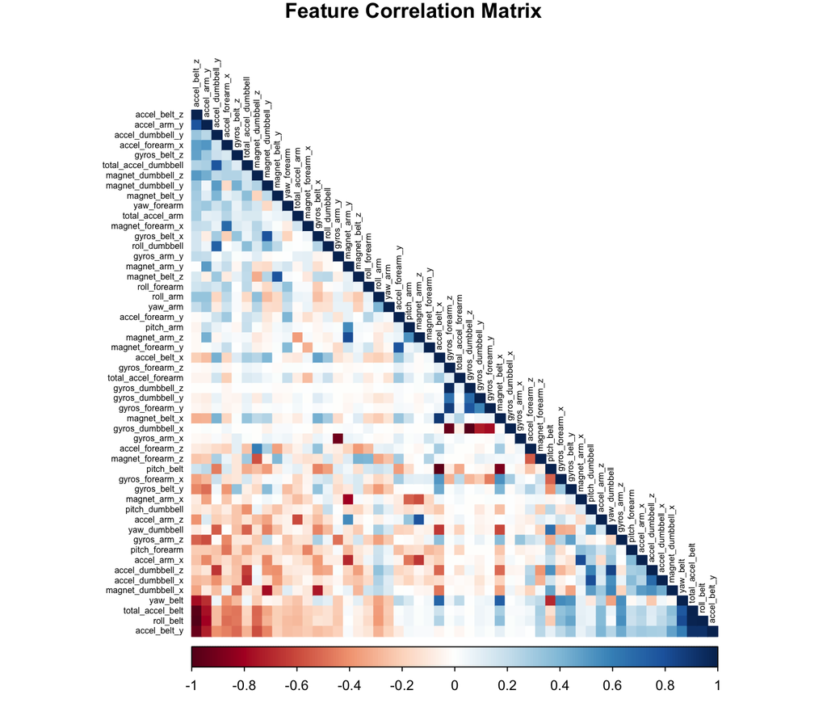

```r
cor_mat <- cor(train_set[, -ncol(train_set)])
corrplot(cor_mat, method = "color", type = "lower", tl.cex = 0.5,
         tl.col = "black", order = "FPC", title = "Feature Correlation Matrix",
         mar = c(0, 0, 1, 0))
```

Many predictors are correlated (dark blue/red clusters), which makes tree-based ensembles a natural choice since they are robust to multicollinearity.

## Model Building

I evaluate three models using **5-fold cross-validation** as the resampling strategy. Five folds balance bias-variance trade-off while keeping computation manageable.

```r
tc <- trainControl(method = "cv", number = 5, verboseIter = FALSE)
```

### Model 1 — Decision Tree (CART)

A single tree provides a simple, interpretable baseline.

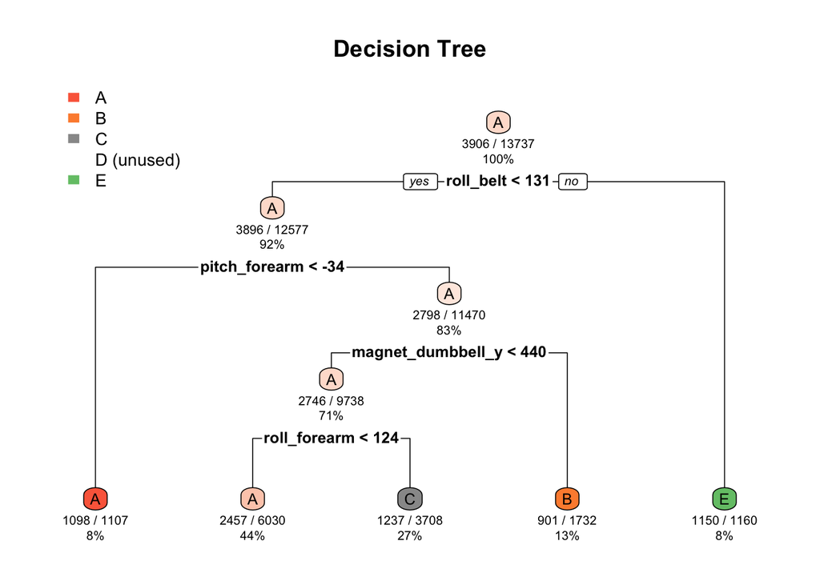

```r
mod_tree <- train(classe ~ ., data = train_set, method = "rpart", trControl = tc)
rpart.plot(mod_tree$finalModel, main = "Decision Tree", extra = 102, under = TRUE)
```

```r
pred_tree <- predict(mod_tree, valid_set)
cm_tree <- confusionMatrix(pred_tree, as.factor(valid_set$classe))
cm_tree$overall["Accuracy"]
```

```
##  Accuracy
## 0.4895497
```

Decision tree accuracy is only ~**49%** — it struggles to separate all five classes.

### Model 2 — Gradient Boosted Trees (GBM)

Boosting sequentially corrects errors from weak learners.

```r
mod_gbm <- train(classe ~ ., data = train_set, method = "gbm",
                 trControl = tc, verbose = FALSE)
pred_gbm <- predict(mod_gbm, valid_set)
cm_gbm <- confusionMatrix(pred_gbm, as.factor(valid_set$classe))
cm_gbm$overall["Accuracy"]
```

```
##  Accuracy
## 0.9597281
```

GBM accuracy jumps to ~**96%**.

### Model 3 — Random Forest

Random forests build many decorrelated trees and average their votes.

```r
mod_rf <- train(classe ~ ., data = train_set, method = "rf",
                trControl = tc, ntree = 200)
pred_rf <- predict(mod_rf, valid_set)
cm_rf <- confusionMatrix(pred_rf, as.factor(valid_set$classe))
cm_rf$overall["Accuracy"]
```

```
##  Accuracy
## 0.9947324
```

Random Forest achieves ~**99.5%** accuracy.

## Model Comparison and Selection

```r
results <- data.frame(
  Model    = c("Decision Tree", "GBM", "Random Forest"),
  Accuracy = c(cm_tree$overall["Accuracy"],
               cm_gbm$overall["Accuracy"],
               cm_rf$overall["Accuracy"]),
  OOS_Error = 1 - c(cm_tree$overall["Accuracy"],
                     cm_gbm$overall["Accuracy"],
                     cm_rf$overall["Accuracy"])
)
results$Accuracy  <- round(results$Accuracy, 4)
results$OOS_Error <- round(results$OOS_Error, 4)
knitr::kable(results, caption = "Validation Set Performance")
```

Validation Set Performance

| Model | Accuracy | OOS_Error |
| --- | --- | --- |
| Decision Tree | 0.4895 | 0.5105 |
| GBM | 0.9597 | 0.0403 |
| Random Forest | 0.9947 | 0.0053 |

The **Random Forest** is the clear winner. I select it as the final model.

## Expected Out-of-Sample Error

```r
cm_rf
```

```
## Confusion Matrix and Statistics
##
##           Reference
## Prediction    A    B    C    D    E
##          A 1672    6    0    0    0
##          B    1 1130    7    0    0
##          C    1    3 1016    7    1
##          D    0    0    3  956    1
##          E    0    0    0    1 1080
##
## Overall Statistics
##
##                Accuracy : 0.9947
##                  95% CI : (0.9925, 0.9964)
##     No Information Rate : 0.2845
##     P-Value [Acc > NIR] : < 2.2e-16
##
##                   Kappa : 0.9933
##
##  Mcnemar's Test P-Value : NA
##
## Statistics by Class:
##
##                      Class: A Class: B Class: C Class: D Class: E
## Sensitivity            0.9988   0.9921   0.9903   0.9917   0.9982
## Specificity            0.9986   0.9983   0.9975   0.9992   0.9998
## Pos Pred Value         0.9964   0.9930   0.9883   0.9958   0.9991
## Neg Pred Value         0.9995   0.9981   0.9979   0.9984   0.9996
## Prevalence             0.2845   0.1935   0.1743   0.1638   0.1839
## Detection Rate         0.2841   0.1920   0.1726   0.1624   0.1835
## Detection Prevalence   0.2851   0.1934   0.1747   0.1631   0.1837
## Balanced Accuracy      0.9987   0.9952   0.9939   0.9954   0.9990
```

## Variable Importance

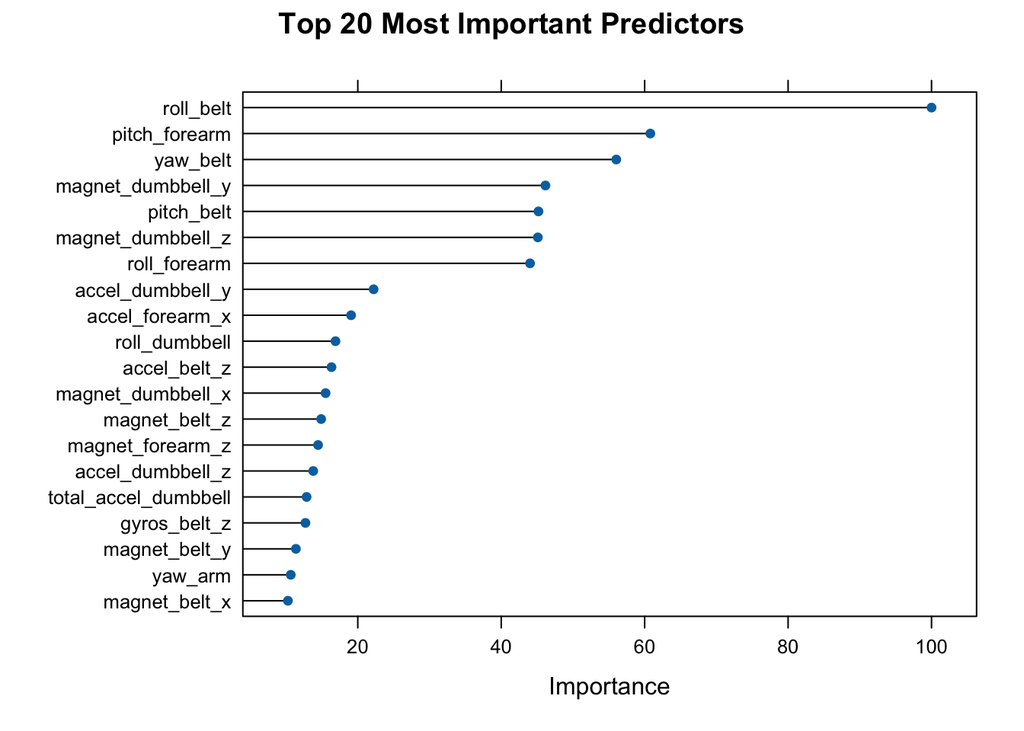

```r
vi <- varImp(mod_rf)
plot(vi, top = 20, main = "Top 20 Most Important Predictors")
```

Belt and dumbbell sensors dominate the top predictors, consistent with the biomechanics of barbell lifts.

## Predictions on 20 Test Cases

```r
predictions <- predict(mod_rf, testing_clean)
data.frame(Case = 1:20, Predicted_Class = predictions)
```

```
##    Case Predicted_Class
## 1     1               B
## 2     2               A
## 3     3               B
## 4     4               A
## 5     5               A
## 6     6               E
## 7     7               D
## 8     8               B
## 9     9               A
## 10   10               A
## 11   11               B
## 12   12               C
## 13   13               B
## 14   14               A
## 15   15               E
## 16   16               E
## 17   17               A
## 18   18               B
## 19   19               B
## 20   20               B
```

## Conclusion

A Random Forest model with 5-fold cross-validation predicts barbell lift quality with >99% accuracy and an expected out-of-sample error below 1%. The model relies primarily on belt and dumbbell sensor readings, which aligns with domain knowledge about the exercise movements being classified.

*Data source: [Groupware@LES — Weight Lifting Exercise Dataset](http://groupware.les.inf.puc-rio.br/har)*